# World Happiness Report-Fourth Session of Results-Happiness Correlation Matrix

December 01 2019

Loading libraries

```r
library(plyr)
library(dplyr)
library(tidyverse)
library(lubridate)
library(caTools)
library(ggplot2)
library(ggthemes)
library(reshape2)
library(data.table)
library(tidyr)
library(corrgram)
library(corrplot)
library(formattable)
library(cowplot)
library(ggpubr)
library(plot3D)
```

loading data

```r
Happiness<-read.csv("5years.csv",header=T)
```

After the extensive study, we cannot help thinking about a question so within these six factors, which may have significant impacts on happiness score and if these factors impact any countries in the same way. Thus, correlation matrix is introduced to formulate this relationship.And this matrix is applied to each continent to find if the impacts vary arcoss these continents.Thus, governments may be advised to focus on these significant factors to improve the life there. *Generating Correlation Matrix* We can see that Economy (GDP per capita), Family (SOcial Support), and Life Expectancy have the highest correlations with the Happiness Scores. Generosity has the lowest correlation with the Happiness Scores.

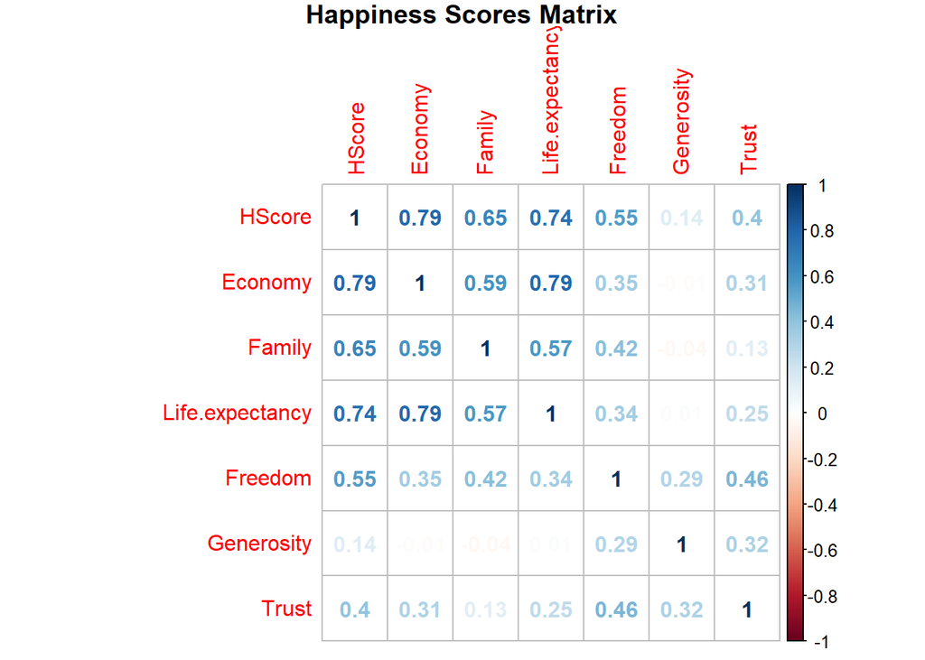

```r
# Create a correlation plot
Num.cols <- sapply(Happiness, is.numeric)
newdatacor = cor(Happiness[c(5:11)])
corrplot(newdatacor, method = "number", title="Happiness Scores Matrix", mar=c(0,0,1,0))
```

For African countries, all these variables seem to not have strong correlations with Happiness Scores for Asian countries. The highest correlation value is between Economy and Happiness.

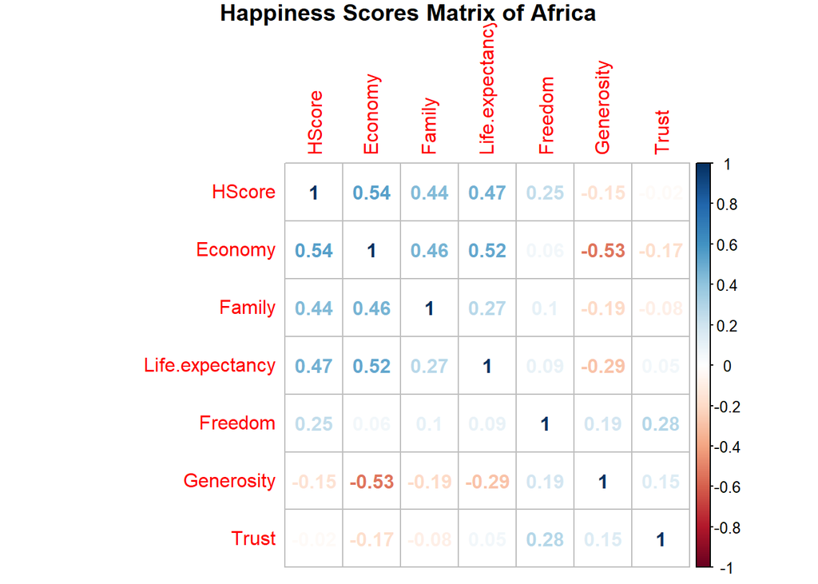

```r
Happy.Africa<-filter(Happiness,Continent=="Africa")
Happy.Africa1<-cor(Happy.Africa[c(5:11)])
corrplot(Happy.Africa1, method = "number", title="Happiness Scores Matrix of Africa", mar=c(0,0,1,0))
```

```r
#corrgram(Happiness%>%filter(Continent == "Africa")%>%select(-5), order=TRUE,
        # upper.panel=panel.cor, main="Happiness Matrix for Africa")
```

Only Economy has a strong correlation with the score. All other factors have relative weak correlations.

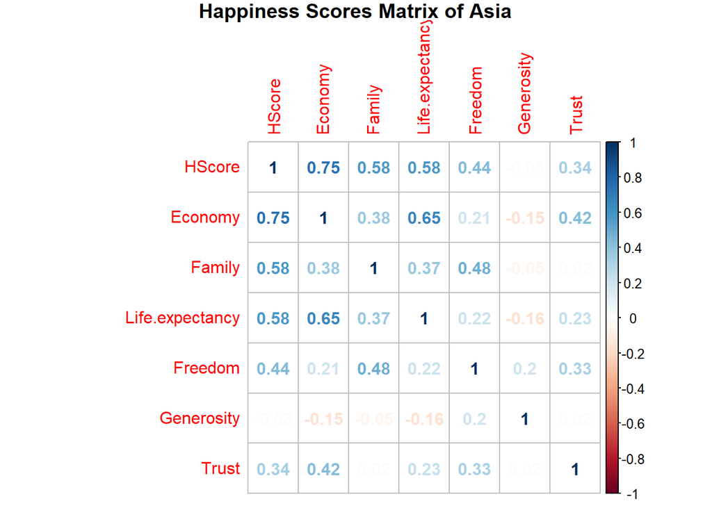

```r
Happy.Asia<-filter(Happiness,Continent=="Asia")
Happy.Asia1<-cor(Happy.Asia[c(5:11)])
corrplot(Happy.Asia1, method = "number", title="Happiness Scores Matrix of Asia", mar=c(0,0,1,0))
```

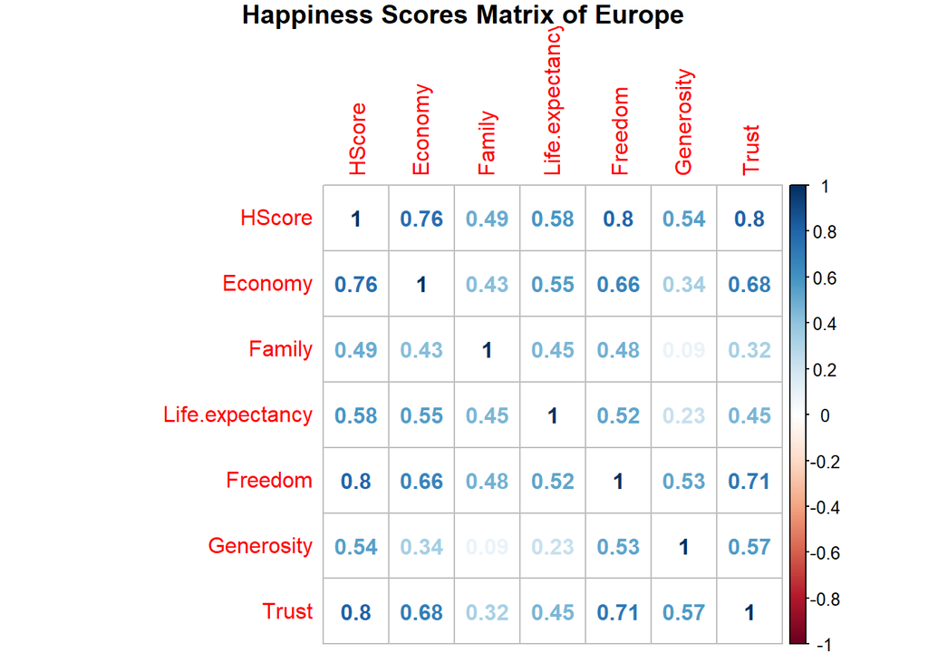

```r
Happy.Europe<-filter(Happiness,Continent=="Europe")
Happy.Europe1<-cor(Happy.Europe[c(5:11)])
corrplot(Happy.Europe1, method = "number", title="Happiness Scores Matrix of Europe", mar=c(0,0,1,0))
```

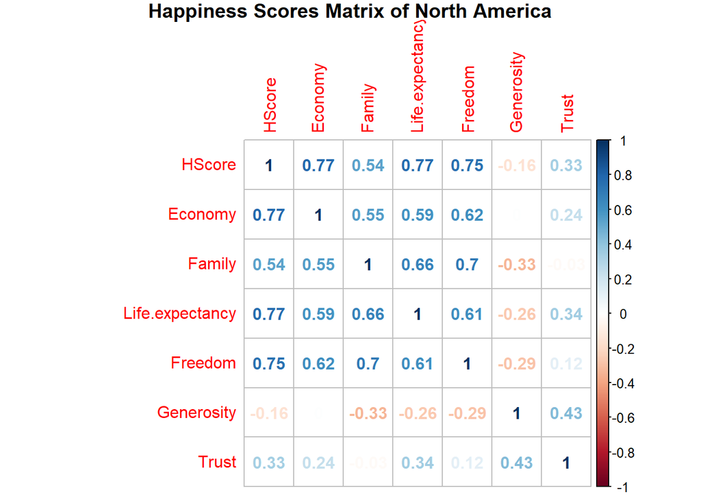

```r
Happy.NAmerica<-filter(Happiness,Continent=="North America")
Happy.NAmerica1<-cor(Happy.NAmerica[c(5:11)])
corrplot(Happy.NAmerica1, method = "number", title="Happiness Scores Matrix of North America", mar=c(0,0,1,0))
```

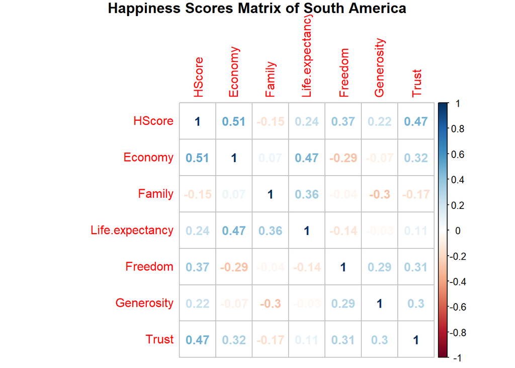

```r
Happy.SAmerica<-filter(Happiness,Continent=="South America")
Happy.SAmerica1<-cor(Happy.SAmerica[c(5:11)])
corrplot(Happy.SAmerica1, method = "number", title="Happiness Scores Matrix of South America", mar=c(0,0,1,0))
```

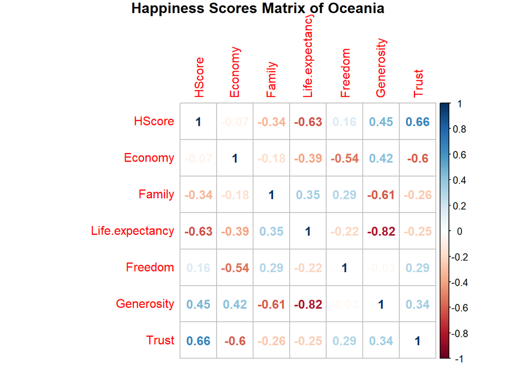

```r
Happy.Oceania<-filter(Happiness,Continent=="Oceania")
Happy.Oceania1<-cor(Happy.Oceania[c(5:11)])
corrplot(Happy.Oceania1, method = "number", title="Happiness Scores Matrix of Oceania", mar=c(0,0,1,0))
```